# Vertical Profile of Wind Speed

Hao-Ran Wu ( haoranwu @ zju.edu.cn )

2022-09-14

In this section we are concerned about how to generate wind speed profile through the function `ws()`.

## Code Example(s)

```r
# Generate Vertical Profile of Wind Speed
# ********************************
#
# Calculate wind speed at different heights above ground level.
#
# ********************************
# List of variables and units for this example
#
# 'z'         height above ground level (m)
# 'uz'        horizontal wind speed (m s−1) at height z (m)
#
# ********************************
# Step 1: import package
require(bproce)

# Step 2: choose parameters
z <- seq(1, 10, 0.1)

# Step 3: run the model
uz <- ws(z, mode = "windz")

# Step 4: visualize the result
plot(
  uz, z, type = "l",
  xlab = "Horizontal wind speed",
  ylab = "Height above ground level",
  main = "Vertical Profile of Wind Speed"
)
```

## Explanation

**Step1:** Load the package `bproce` through the `require()` function.

```r
require(bproce)
```

**Step2:** Choose model parameters.

```r
z <- seq(1, 10, 0.1)

cat("Height above ground level (m):", head(z), "...", tail(z), "\n")
```

```
Height above ground level (m): 1 1.1 1.2 1.3 1.4 1.5 ... 9.5 9.6 9.7 9.8 9.9 10
```

**Step3:** Run the model. The wind profile of homogeneous vegetation under neutral atmospheric conditions is typically expressed as a logarithmic function of height ($z$) from the ground, where horizontal wind speed ($U$) decreases at heights approaching the ground, as a consequence of surface’s drag effects:

$$U(z)=\frac{u^*}{\kappa}·\ln(\frac{z-d}{z_0})$$

where $U(z)$ is the horizontal wind speed (m s<sup>−1</sup>) at height $z$ (m); $u^∗$ is the friction velocity (m s<sup>−1</sup> ), $\kappa$ is the von Karmon constant with an average value of 0.35 – 0.43 (a value of 0.40 is often used in the literature), $d$ (m) is a zero plain displacement, and $z_0$ is the roughness length (m) at which is $U$ is near zero. Note that $z-d$ must be a positive value, so values of $z$ which are smaller than the displacement coefficient $d$ will be automatically ignored.

```r
uz <- ws(z, mode = "windz")

print(head(data.frame(z=z, uz=uz)), digits = 3)
```

```
      z   uz
1   1.0 1.03
1.1 1.1 1.06
1.2 1.2 1.08
1.3 1.3 1.10
1.4 1.4 1.12
1.5 1.5 1.14
```

The arguments and their meaning of the function `ws()` that might change the calculated result in this example are shown in the table below:

[output not shown]

**Step 4:** Visualize the result. Create a line plot of height against predicted wind speed through the function `plot()`:

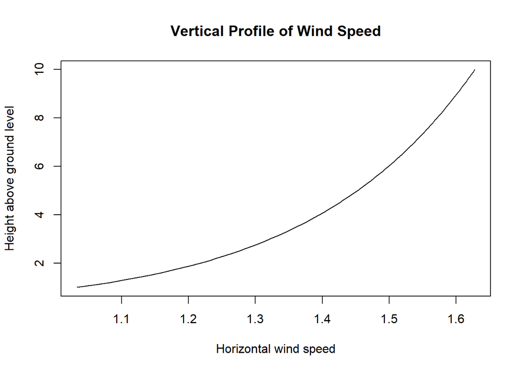

```r
plot(
  uz, z, type = "l",
  xlab = "Horizontal wind speed",
  ylab = "Height above ground level",
  main = "Vertical Profile of Wind Speed"
)
```